# Immune explainer

Jeffrey A. Walker

19 July, 2021

# Recognition

Our immune system is only partly about our own cells (***self**) versus cells that have invaded us (**non-self**). A better way to think about the immune system is, the immune system defends our body against “bad”: **pathogens**, **parasites**, toxins (including **venoms** and **poisons**), and our own cells that are damaged, or **tumorogenic**, or colonized by **virus**. A properly functioning immune system does not attack “good”: our own, healthy cells, our own molecules, and symbiotic organisms that are “good” for us (these are mostly bacteria). Not attacking “good” is due to **immune tolerance**, which is an amazing property that we will not cover.

Our immune system uses several families of **receptor proteins** to recognize “good” from “bad”. These receptors may be bound to the plasma membrane, or inside the cell or even secreted.

1. Innate immune cells, and even non-immune cells, use **pattern recognition receptors (PRRs)** – each of these is specific to a different **pathogen associated molecular pattern (PAMP)** from **non-self** cells, or a **damage associated molecular pattern (DAMP)** from **self** cells.
2. NK cells are innate but use a different set of receptors.
3. Lymphocytes use **T cell receptors (TCRs)** and **B-cell receptors (BCRs)** that are specific to **antigens**, which are bits of protein (both self and non-self) that stimulate the adaptive immune response.

Big picture take home message number 1: innate receptors recognize PAMPs/DAMPs and adaptive receptors recognize antigen.

Antigen tends to be protein; these could be from inside the pathogen, or could be part of a cell wall or plasma membrane, or could be a secreted protein. Some proteins that function as antigen also function as PAMPs – an example is flagellin, an abundant protein in a bacterial flagellum.

Big picture take home message number 2: A key difference between PRRs and TCR/BCRs is,

- a PRR specific to a certain PAMP can bind this PAMP regardless of what organism it comes from (that is, the PAMP may be found on very different organisms (say different kinds of bacteria or even a yeast and a protist). That is, PRR recognition is for common molecules found in frequntly encountered pathogens. Because of this, PRR recognition is **germline encoded** – that is, determined by the genes we inherit from our parents.
- a TCR/BCR specific to a certain antigen is extremely specific to the organism it comes from. For example, haemagglutinin is a influenza virus protein that is uses to attach to and enter epithelial cells of our respiratory tract. The gene encoding the protein evolves rapidly and the TCR that binds to the haemagglutinin from one strain of flu virus may not bind to the haemagglutinin from a different strain. Amazingly, the t cells and b cells will evolve in response to the different TCRs/BCRs specific to each strain! This is the adaptation in the adiptive immune system. This means that TCR/BCR recognition is **acquired** and is a function of what antigens we are exposed to.

# Innate

I like this summary of the innate immune system

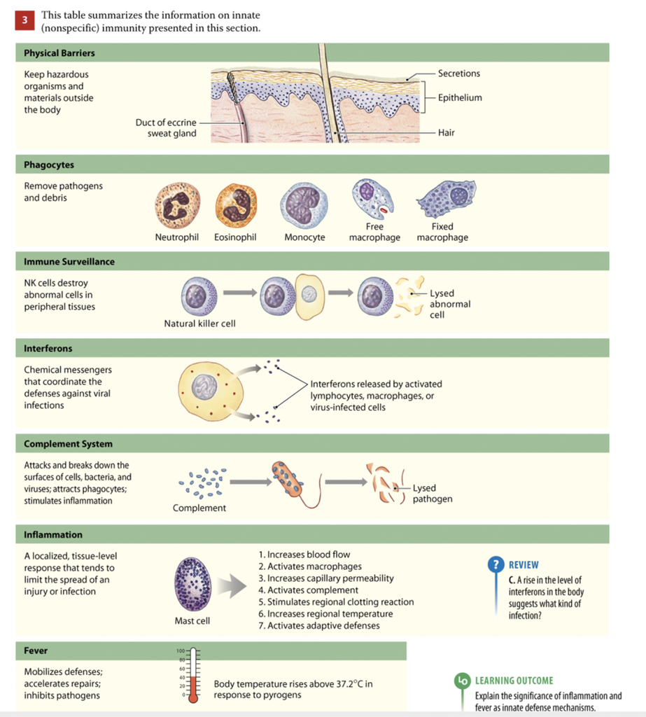

1. A key is the function of interferon in antiviral signaling.
2. A key is the function of NK cells in **immune surveillance**. The functio of NK cells is exactly like that of Tc cells (see below) except that NK cells are not antigen specific.

# Adaptive immune system and “immunity”

## How to kickstart the adaptive immune system

**Dendritic cells (DCs)** (a type of monocyte/macrophage) hang out in the periphery where colonization by pathogen is likely and sample the environment by pinocytosis of interstitial fluid (which might contain virus or secretions from bacteria or yeast) or phagocytosis of whole cells, which might include bacteria or yeast or self cells infected by virus or self cells that are tumorogenic. The DCs enter the lymph and travel to secondary lymphoid organs such lymph nodes, tonsils, and MALT. Along the way, the dendritic cells break the ingested proteins into fragments, attach the fragments to **MHC** protein, then shuttle the MHC-antigen complex to the plasma membrane. In the lymphoid tissue, they “present” the antigen to T and B lymphocytes – this is called **antigen presentation**. Note that “antigen” can refer both the whole protein or the protein fragment attached to the MHC.

Within the lymph tissue there are many thousands of **clones** of T cells, each clone differs from all others in the antigen-binding site of the antigen receptor - this is what makes them specific. All of these cells are **naive** – they haven’t been activated because they haven’t been presented to the antigen. When the DC presenting the MHC-antigen bumps into a naive T cell from a clone that expresseses an antigen receptor that is specific to the antigen, then the antigen receptor-antigen-MHC complex binds the lympocyte to the dendritic cell. The dendritic cell secretes cytokines that bind to the T cell. The combination of both these signals activates the T cell. The T cell then goes through many rounds of cell division – called **clonal expansion** – making thousands of copies of the clone that expresses the antigen receptor that is specific to the antigen.

This is the adaptive response in a nutshell. The details are highly complex and highly variable and there are still many, many unknowns, so let’s keep what is known simple.

- a little deeper 1 – there are two MHC proteins, **MHC-I** and **MHC-II**. All cells (except RBCs) express **MHC-I**. Dendritic cells *also* express **MHC-II**.
- a little deeper 2 – Macrophages and B cells can also present antigens to T cells, but this is really the specialty of dendritic cells. And B-cell presentation to T cells is not to activate the T cell but to activate the B-cell (see below). Macrophages and B-cells also express MHC-II in addition to MHC-I. Cells that express MHC-II are sometimes called **professional antigen presenting cells**. Confusingly, the term “antigen presenting cell” (**APC**) can sometimes refer to professional antigen presenting cells that express MHC-II and sometimes refer to any cell expresing antigen using MHC-I.

## What are the lymphocytes that hang out in the secondary lymphoid tissue, waiting to be activated by antigen presentation?

1. **helper T cells (Th cells)**
- elementary function – Activated Th cells activate B cells, sometimes help activate Tc cells, and secrete cytokines that stimulate innate white blood cells.
- more detail on activation – The TCR of Th cells binds to MHC-II-antigen commplex on the dendritic cell. Another protein called **CD4** on the Th cell also binds to the MHC-II on the dendritic cell. Tc cells do not express CD4 so Th cells are often called **CD4+** (or just CD4) T cells (the “+” means that they express CD4)
2. **cytotoxic T cells (Tc cells)**
- elementary function – Activated Tc cells function just like NK cells – they target our own cells that have been infected by virus or our own cells that have acquired tumorogenic mutations. Tc cells bind to the target cell and secrete **perforin** and **granzymes** that cause the target cell to **lyse** and/or undergo **apoptosis**. Cell lysis occurs when the plasma membrane cannot regulate water transport and water moves into the cell (because the cytoplasm is hyperosmotic) which puts strain on the plasma membrane which causes it to fragment. This causes cell death. Apoptosis is **programmed cell death** which is stimulated by death factor proteins that inhibit protein synthesis pathways. Without proteins, the cell cannot function and it dies).
- more detail on binding to target cell - Again, target cells are in the periphery and have been infected by virus or have mutated genes that has converted the cell to being tumorogenic. Again, target cells are any cell type that expresses MHC-I, which is all cells but RBCs. The target cell binds the viral protein fragments or tumor protein fragments to the MHC-I moves the MHC-I-antigen to the plasma membrane, signaling “kill me”. Tc cells bind to the target cell via the TCR. A protein called **CD8** expressed on the Tc cell also binds to the MHC-I on the target cell. Th cells do not express CD8 so Tc cells are also called **CD8+** T cells to distinguis them from Th cells (which are CD4+).
- more detail on Tc cell activation – Tc cells do not need to be activated in lymphoid tissue by professional APCs but can be activated in the periphery by target cells expressing MHC-I-antigen. But, at the start of an infection, there are not enough naive Tc cells in the periphery to clear a virus so activation in lymphoid tissue is critical. To activate naive Tc cells in lymphoid tissue, dendritic cells that have endocytosed antigen migrate to the lymphoid tissue and present the antigen to naive Tc cells. The Tc cell then undergoes massive clonal expansion and migrates to the periphery to clear the clone.
3. **B cells**
- elementary function – naive B cells hang out in the lymphoid tissue and are activated by Th cells. Activated B cells go through clonal expansion and mature into **plasma** cells that synthesize and secrete **antibody**. Antibodies are proteins that are essentially B cell receptors that bind antigen. Secreted antibody binds to free antigen and can **neutralize** it, which means keep it from being active in our body. For example, antibody bound to antigen on a virus could keep the virus from entering a cell or from leaving a cell. Or antibody bound to a toxin could inhibit the toxin from binding to our cells. Don’t worry about the different classes of antibody.
- more detail on activation – B-cells endocytose antigen bound to the BCR, process the antigen, bind it to MHC-II (because B cells are professional APCs) and present the antigen to activated Th cells (I said activated!) that express a TCR that is specific to the same antigen.

Summary

- MHC-II is expressed only on professional APCs (dendritic cells, macrophages, B cells)
- antigen bound to MHC-II is presented to CD4+ Th cells. This can be to activate the Th cell if the APC is a dendritic cell or to activate the B cell, if the APC is a B cell.
- antigen bound to MHC-I is presented to CD8+ Tc cells. This can be to activate the Tc cell if the APC is a dendritic cell or to signal “kill me” if the APC is a cell infected by virus or is tumorogenic.